# Analysescript für die Datenauswertung der Erhebung zum Thema *Clickbait*

Fabian Comanns, Peter Gödde, Nicole Herbolt, Insa Menzel

Im Rahmen des Seminars “Usability, User Diversity und Technikakzeptanz” im Wintersemester 2019/2020 an der RWTH Aachen University hat sich der Kurs unter der Leitung von Dr. André Calero-Valdez mit dem Themengebiet “Mis- und Desinformationen im Internet” beschäftigt. Nach eingehender Beschäftigung mit verschiedenen Forschungszweigen hat sich die Gruppe, bestehend aus den oben genannten Autoren, dafür entschieden, den Fokus auf den Forschungszweig “Clickbait” zu legen. Nachdem der bisherige Forschungsstand zum Thema Clickbait grob resümiert wurde, hat sich folgende Forschungsfrage ergeben:

*Welchen Einfluss haben Nutzerfaktoren auf die Erkennung von Clickbait-Schlagzeilen in Online-Medien?*

Dieses Dokument zeigt die Datenbereinigung, -aufbereitung und -auswertung hinsichtlich der Hypothesen, die dazu dienen, die übergeordnete Forschungsfrage zu beantworten. Am Ende des Dokuments werden die Ergebnisse kurz erläutert und weiterführende Untersuchungsaspekte genannt, die im Anschluss an diese Analyse interessant sein könnten.

# Daten laden und bereinigen

# Kategoriale und numerische Variablen generieren

# Schlagzeilen Werte zuordnen

# Faktorenzuweisung

```
##  head_1  head_2  head_3  head_4  head_5  head_6  head_7  head_8  head_9
##      ""      ""      ""      ""      ""      ""      ""      ""      ""
## head_10 head_11 head_12
##      ""      ""      ""
```

```
## Call: psych::scoreItems(keys = head_keys, items = raw.short, min = 0,
##     max = 1)
##
## (Unstandardized) Alpha:
##        pol cult  eco
## alpha 0.15 0.16 0.16
##
## Standard errors of unstandardized Alpha:
##        pol cult  eco
## ASE   0.15 0.12 0.13
##
## Average item correlation:
##             pol  cult   eco
## average.r 0.056 0.038 0.046
##
## Median item correlation:
##    pol   cult    eco
## 0.0601 0.0999 0.0092
##
##  Guttman 6* reliability:
##           pol cult  eco
## Lambda.6 0.26 0.33 0.25
##
## Signal/Noise based upon av.r :
##               pol cult  eco
## Signal/Noise 0.18  0.2 0.19
##
## Scale intercorrelations corrected for attenuation
##  raw correlations below the diagonal, alpha on the diagonal
##  corrected correlations above the diagonal:
##         pol cult   eco
## pol   0.152 1.17 -0.36
## cult  0.185 0.16  1.07
## eco  -0.056 0.18  0.16
##
##  In order to see the item by scale loadings and frequency counts of the data
##  print with the short option = FALSE
```

[output not shown]

[output cut: 8 more lines]

[output not shown]

```
##  BigFive10_1  BigFive10_2  BigFive10_3  BigFive10_4  BigFive10_5
##           ""           ""           ""           ""           ""
##  BigFive10_6  BigFive10_7  BigFive10_8  BigFive10_9 BigFive10_10
##           ""           ""           ""           ""           ""
```

```
## Call: psych::scoreItems(keys = bfi_keys, items = raw.short_1, impute = "median",
##     min = 1, max = 6)
##
## (Unstandardized) Alpha:
##       bfio bfic bfie bfia bfin
## alpha 0.64 0.46 0.75  0.2 0.57
##
## Standard errors of unstandardized Alpha:
##       bfio bfic bfie bfia bfin
## ASE   0.14 0.16 0.13 0.18 0.15
##
## Average item correlation:
##           bfio bfic bfie bfia bfin
## average.r 0.47  0.3  0.6 0.11  0.4
##
## Median item correlation:
## bfio bfic bfie bfia bfin
## 0.47 0.31 0.60 0.11 0.40
##
##  Guttman 6* reliability:
##          bfio bfic bfie bfia bfin
## Lambda.6 0.52  0.4 0.67 0.22 0.48
##
## Signal/Noise based upon av.r :
##              bfio bfic bfie bfia bfin
## Signal/Noise  1.7 0.86    3 0.25  1.3
##
## Scale intercorrelations corrected for attenuation
##  raw correlations below the diagonal, alpha on the diagonal
##  corrected correlations above the diagonal:
##        bfio   bfic   bfie   bfia   bfin
## bfio 0.6358  0.178  0.155  0.403  0.015
## bfic 0.0969  0.464  0.287 -0.033 -0.189
## bfie 0.1070  0.169  0.752  0.029 -0.516
## bfia 0.1436 -0.010  0.011  0.199 -0.068
## bfin 0.0093 -0.097 -0.336 -0.023  0.566
##
##  In order to see the item by scale loadings and frequency counts of the data
##  print with the short option = FALSE
```

[output not shown]

[output cut: 8 more lines]

[output not shown]

```
## InternetSkillScale_1 InternetSkillScale_2 InternetSkillScale_3
##                   ""                   ""                   ""
## InternetSkillScale_4 InternetSkillScale_5 InternetSkillScale_6
##                   ""                   ""                   ""
## InternetSkillScale_7 InternetSkillScale_8
##                   ""                   ""
```

```
## Call: psych::scoreItems(keys = skill_keys, items = raw.short_new, impute = "median",
##     min = 1, max = 6)
##
## (Unstandardized) Alpha:
##       skills
## alpha   0.79
##
## Standard errors of unstandardized Alpha:
##       skills
## ASE    0.046
##
## Average item correlation:
##           skills
## average.r   0.31
##
## Median item correlation:
## skills
##   0.27
##
##  Guttman 6* reliability:
##          skills
## Lambda.6   0.81
##
## Signal/Noise based upon av.r :
##              skills
## Signal/Noise    3.7
##
## Scale intercorrelations corrected for attenuation
##  raw correlations below the diagonal, alpha on the diagonal
##  corrected correlations above the diagonal:
##        skills
## skills   0.79
##
##  In order to see the item by scale loadings and frequency counts of the data
##  print with the short option = FALSE
```

[output not shown]

[output cut: 8 more lines]

[output not shown]

```
## Call: psych::scoreItems(keys = keylist_semdiff, items = raw.short,
##     min = 1, max = 5)
##
## (Unstandardized) Alpha:
##        sz1  sz2  sz3  sz4  sz5  sz6  sz7  sz8  sz9 sz10 sz11 sz12
## alpha 0.82 0.81 0.84 0.88 0.77 0.79 0.83 0.67 0.77 0.79 0.85 0.81
##
## Standard errors of unstandardized Alpha:
##         sz1   sz2   sz3   sz4  sz5   sz6   sz7   sz8   sz9  sz10  sz11
## ASE   0.044 0.045 0.041 0.036 0.05 0.048 0.043 0.063 0.051 0.048 0.039
##        sz12
## ASE   0.044
##
## Average item correlation:
##            sz1  sz2  sz3 sz4  sz5  sz6  sz7  sz8  sz9 sz10 sz11 sz12
## average.r 0.39 0.38 0.43 0.5 0.32 0.35 0.41 0.22 0.32 0.35 0.46 0.39
##
## Median item correlation:
##  sz1  sz2  sz3  sz4  sz5  sz6  sz7  sz8  sz9 sz10 sz11 sz12
## 0.43 0.34 0.48 0.55 0.25 0.34 0.36 0.26 0.38 0.39 0.48 0.40
##
##  Guttman 6* reliability:
##           sz1  sz2  sz3  sz4  sz5  sz6  sz7  sz8  sz9 sz10 sz11 sz12
## Lambda.6 0.97 0.96 0.97 0.97 0.96 0.96 0.97 0.93 0.95 0.96 0.97 0.96
##
## Signal/Noise based upon av.r :
##              sz1 sz2 sz3 sz4 sz5 sz6 sz7 sz8 sz9 sz10 sz11 sz12
## Signal/Noise 4.5 4.3 5.3 7.1 3.4 3.8 4.8   2 3.3  3.7  5.9  4.4
##
## Scale intercorrelations corrected for attenuation
##  raw correlations below the diagonal, alpha on the diagonal
##  corrected correlations above the diagonal:
##         sz1    sz2  sz3    sz4    sz5    sz6   sz7  sz8  sz9   sz10 sz11
## sz1   0.819  0.379 0.28  0.623 -0.022  0.216 0.352 0.38 0.37  0.023 0.47
## sz2   0.310  0.813 0.59  0.102  0.435 -0.030 0.635 0.59 0.31  0.593 0.47
## sz3   0.233  0.488 0.84  0.232  0.371  0.163 0.492 0.51 0.30  0.582 0.42
## sz4   0.528  0.087 0.20  0.877 -0.059  0.555 0.039 0.13 0.41 -0.100 0.35
## sz5  -0.017  0.345 0.30 -0.049  0.771  0.098 0.330 0.40 0.31  0.766 0.41
## sz6   0.174 -0.024 0.13  0.462  0.077  0.790 0.138 0.17 0.32  0.150 0.30
## sz7   0.290  0.521 0.41  0.033  0.264  0.112 0.828 0.52 0.28  0.315 0.43
## sz8   0.283  0.431 0.38  0.100  0.287  0.122 0.388 0.67 0.36  0.513 0.45
## sz9   0.293  0.248 0.24  0.334  0.242  0.248 0.225 0.26 0.77  0.389 0.43
## sz10  0.019  0.475 0.47 -0.083  0.597  0.119 0.254 0.37 0.30  0.789 0.42
## sz11  0.395  0.395 0.36  0.307  0.335  0.243 0.366 0.34 0.35  0.346 0.85
## sz12  0.019  0.315 0.52 -0.012  0.557  0.221 0.210 0.16 0.24  0.563 0.26
##        sz12
## sz1   0.024
## sz2   0.386
## sz3   0.631
## sz4  -0.014
## sz5   0.703
## sz6   0.276
## sz7   0.255
## sz8   0.219
## sz9   0.302
## sz10  0.702
## sz11  0.315
## sz12  0.815
##
##  In order to see the item by scale loadings and frequency counts of the data
##  print with the short option = FALSE
```

[output not shown]

[output cut: 8 more lines]

[output not shown]

```
## Call: psych::scoreItems(keys = sd_group, items = datensatz_raw, min = 1,
##     max = 5)
##
## (Unstandardized) Alpha:
##       sd_c sd_nc sd_all
## alpha 0.82  0.64   0.82
##
## Standard errors of unstandardized Alpha:
##        sd_c sd_nc sd_all
## ASE   0.044 0.076  0.035
##
## Average item correlation:
##           sd_c sd_nc sd_all
## average.r 0.39  0.26   0.27
##
## Median item correlation:
##   sd_c  sd_nc sd_all
##   0.37   0.27   0.28
##
##  Guttman 6* reliability:
##          sd_c sd_nc sd_all
## Lambda.6 0.84  0.71   0.86
##
## Signal/Noise based upon av.r :
##              sd_c sd_nc sd_all
## Signal/Noise  4.5   1.8    4.5
##
## Scale intercorrelations corrected for attenuation
##  raw correlations below the diagonal, alpha on the diagonal
##  corrected correlations above the diagonal:
##        sd_c sd_nc sd_all
## sd_c   0.82  0.62   1.12
## sd_nc  0.45  0.64   1.06
## sd_all 0.92  0.77   0.82
##
##  In order to see the item by scale loadings and frequency counts of the data
##  print with the short option = FALSE
```

```
## Call: psych::scoreItems(keys = sdressort_keys, items = datensatz, min = 1,
##     max = 5)
##
## (Unstandardized) Alpha:
##       sd_pol sd_cult sd_eco
## alpha   0.56     0.7   0.73
##
## Standard errors of unstandardized Alpha:
##       sd_pol sd_cult sd_eco
## ASE     0.11   0.068  0.075
##
## Average item correlation:
##           sd_pol sd_cult sd_eco
## average.r    0.3    0.32    0.4
##
## Median item correlation:
##  sd_pol sd_cult  sd_eco
##    0.23    0.24    0.39
##
##  Guttman 6* reliability:
##          sd_pol sd_cult sd_eco
## Lambda.6   0.69    0.76   0.73
##
## Signal/Noise based upon av.r :
##              sd_pol sd_cult sd_eco
## Signal/Noise    1.3     2.3    2.6
##
## Scale intercorrelations corrected for attenuation
##  raw correlations below the diagonal, alpha on the diagonal
##  corrected correlations above the diagonal:
##         sd_pol sd_cult sd_eco
## sd_pol    0.56    0.63   0.83
## sd_cult   0.39    0.70   0.72
## sd_eco    0.53    0.52   0.73
##
##  In order to see the item by scale loadings and frequency counts of the data
##  print with the short option = FALSE
```

# Semantisches Differenzial Politik

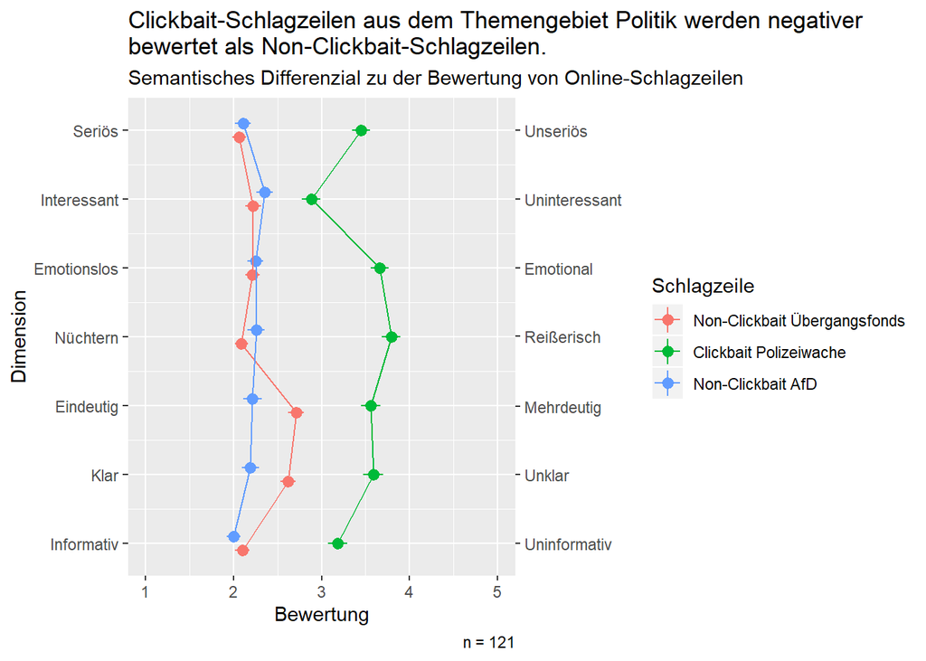

# Semantisches Differenzial Kultur

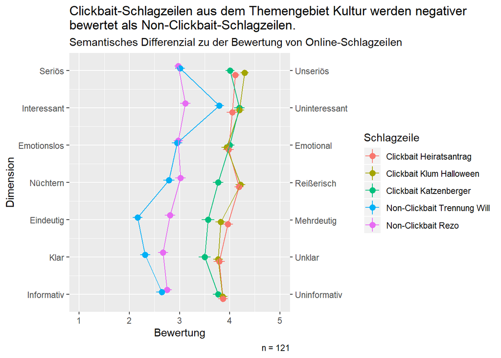

# Semantisches Differenzial Wirtschaft

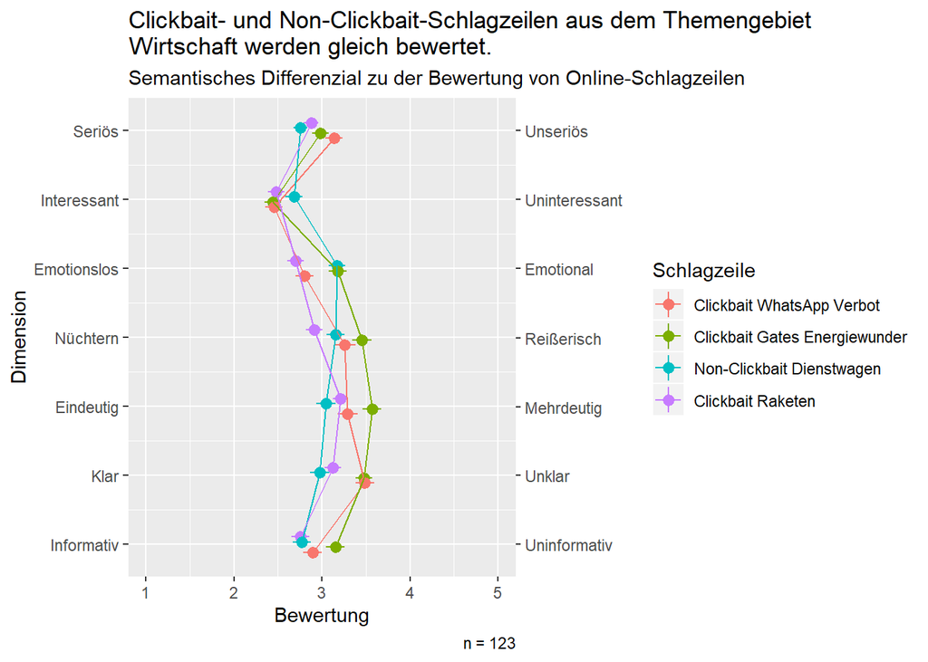

# Deskriptive Statistik

```
##                   vars   n  mean    sd median trimmed  mad   min   max
## Gender*              1 121  2.54  0.52   3.00    2.56 0.00  1.00  3.00
## Age                  2 121 28.40 11.97  24.00   25.73 2.97 15.00 73.00
## Ausbildung*          3 121  4.98  1.20   6.00    5.12 0.00  1.00  6.00
## BeruflTaetigkeit*    4 121   NaN    NA     NA     NaN   NA   Inf  -Inf
## AnteilClickbait_1    5 121  7.33  1.62   8.00    7.35 1.48  3.00 12.00
## Kommentare*          6   7   NaN    NA     NA     NaN   NA   Inf  -Inf
## head_1               7 121  0.74  0.44   1.00    0.79 0.00  0.00  1.00
## head_2               8 121  0.50  0.50   0.00    0.49 0.00  0.00  1.00
## head_3               9 121  0.49  0.50   0.00    0.48 0.00  0.00  1.00
## head_4              10 121  0.75  0.43   1.00    0.81 0.00  0.00  1.00
## head_5              11 121  0.04  0.20   0.00    0.00 0.00  0.00  1.00
## head_6              12 121  0.73  0.45   1.00    0.78 0.00  0.00  1.00
## head_7              13 121  0.73  0.45   1.00    0.78 0.00  0.00  1.00
## head_8              14 121  0.60  0.49   1.00    0.62 0.00  0.00  1.00
## head_9              15 121  0.77  0.42   1.00    0.84 0.00  0.00  1.00
## head_10             16 121  0.14  0.35   0.00    0.05 0.00  0.00  1.00
## head_11             17 121  0.28  0.45   0.00    0.23 0.00  0.00  1.00
## head_12             18 121  0.17  0.37   0.00    0.08 0.00  0.00  1.00
## pol                 19 121  0.66  0.28   0.67    0.68 0.49  0.00  1.00
## cult                20 121  0.37  0.18   0.40    0.37 0.00  0.00  1.00
## eco                 21 121  0.52  0.25   0.50    0.52 0.37  0.00  1.00
## bfio                22 121  4.10  1.08   4.00    4.12 1.48  1.50  6.00
## bfic                23 121  4.10  0.90   4.00    4.10 0.74  2.00  6.00
## bfie                24 121  4.13  1.04   4.00    4.19 0.74  1.00  6.00
## bfia                25 121  3.90  0.79   4.00    3.92 0.74  2.00  5.50
## bfin                26 121  3.27  1.06   3.50    3.23 1.48  1.00  6.00
## skills              27 121  5.10  0.66   5.25    5.19 0.37  2.50  6.00
## sz1                 28 121  2.29  0.63   2.29    2.27 0.64  1.00  4.00
## sz2                 29 121  3.17  0.76   3.14    3.19 0.85  1.00  5.00
## sz3                 30 121  3.45  0.84   3.57    3.47 0.85  1.00  5.00
## sz4                 31 121  2.20  0.78   2.14    2.16 0.85  1.00  4.43
## sz5                 32 121  3.83  0.76   3.86    3.89 0.85  1.00  5.00
## sz6                 33 121  2.81  0.75   2.71    2.80 0.64  1.00  5.00
## sz7                 34 121  2.94  0.78   3.00    2.93 0.85  1.00  5.00
## sz8                 35 121  2.86  0.59   2.86    2.86 0.42  1.00  4.43
## sz9                 36 121  2.90  0.69   2.86    2.91 0.64  1.00  4.57
## sz10                37 121  3.99  0.74   4.14    4.06 0.64  1.00  5.00
## sz11                38 121  3.04  0.87   3.00    3.03 0.85  1.00  5.00
## sz12                39 121  4.01  0.74   4.14    4.07 0.64  1.00  5.00
```

[output cut: 37 more lines]

```
## sz4                3.43  0.35    -0.62 0.07
## sz5                4.00 -0.80     0.68 0.07
## sz6                4.00  0.23     0.05 0.07
## sz7                4.00 -0.01     0.21 0.07
## sz8                3.43 -0.17     0.38 0.05
## sz9                3.57 -0.07    -0.09 0.06
## sz10               4.00 -0.96     1.11 0.07
## sz11               4.00 -0.07    -0.34 0.08
## sz12               4.00 -0.92     1.05 0.07
## sd_c               3.08 -0.40     0.64 0.05
## sd_nc              2.74  0.10     0.17 0.04
## sd_all             2.77 -0.36     1.06 0.04
## sd_pol             2.81  0.10    -0.11 0.05
## sd_cult            3.46 -1.08     3.87 0.05
## sd_eco             2.82 -0.10     0.17 0.05
```

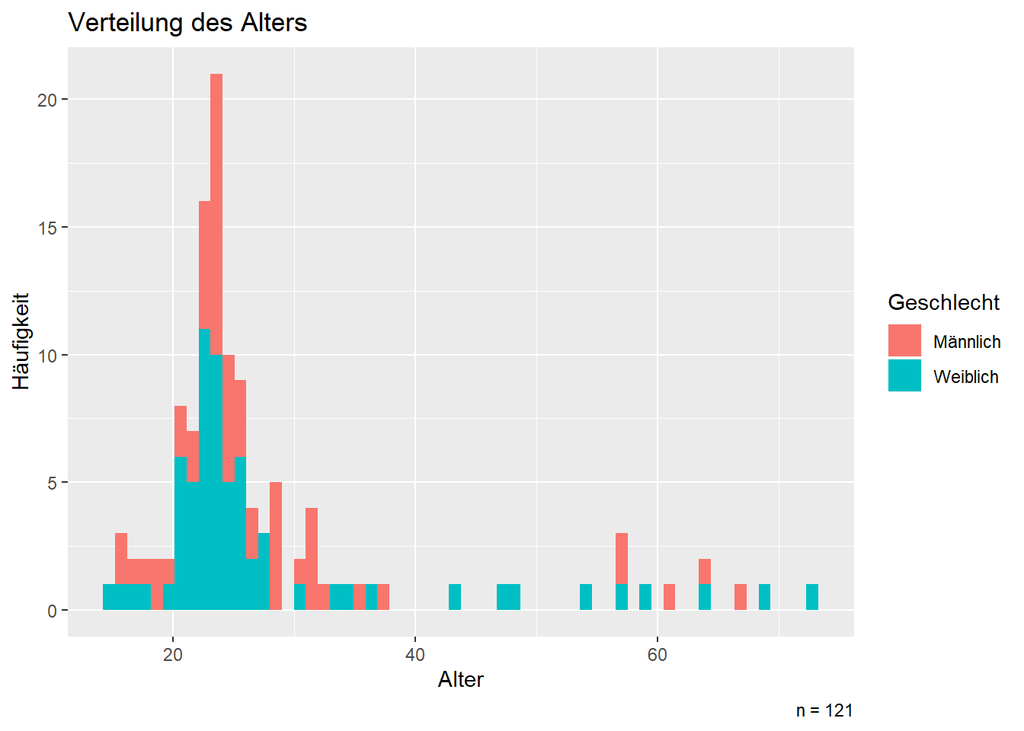

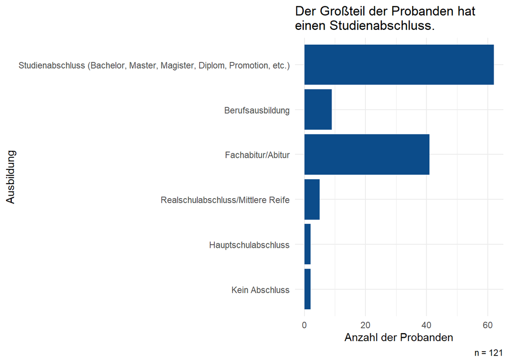

# Inferenzstatistik

```r
#Summierte Themenzuordnung
datensatz <- datensatz %>% rowwise %>% mutate(score = head_1 + head_2 + head_3 + head_4 + head_5 + head_6 + head_7 + head_8 + head_9 + head_10 + head_11 + head_12)

datensatz <- datensatz %>% rowwise %>%  mutate(score_c = head_2 + head_3 + head_5 + head_8 + head_10 + head_11 + head_12)

datensatz <- datensatz %>% rowwise %>% mutate(score_nc = head_1 + head_4 + head_6 + head_7 + head_9)



#H1: Es gibt einen Zusammenhang zwischen dem Alter und der Erkennung von Clickbait-Schlagzeilen.

cor.test(data = datensatz, ~Age+score)
```

```
##
##  Pearson's product-moment correlation
##
## data:  Age and score
## t = 0.079007, df = 119, p-value = 0.9372
## alternative hypothesis: true correlation is not equal to 0
## 95 percent confidence interval:
##  -0.1714758  0.1854991
## sample estimates:
##         cor
## 0.007242374
```

```r
cor.test(data = datensatz, ~Age+score_c)
```

```
##
##  Pearson's product-moment correlation
##
## data:  Age and score_c
## t = 0.59781, df = 119, p-value = 0.5511
## alternative hypothesis: true correlation is not equal to 0
## 95 percent confidence interval:
##  -0.1249985  0.2309596
## sample estimates:
##        cor
## 0.05471889
```

```r
cor.test(data= datensatz, ~Age+score_nc)
```

```
##
##  Pearson's product-moment correlation
##
## data:  Age and score_nc
## t = -0.51935, df = 119, p-value = 0.6045
## alternative hypothesis: true correlation is not equal to 0
## 95 percent confidence interval:
##  -0.2241491  0.1320623
## sample estimates:
##         cor
## -0.04755526
```

```r
#H2: Es gibt einen Unterschied zwischen Männern und Frauen in der Erkennung von Clickbait-Schlagzeilen.

## Recoding datensatz$Gender into datensatz$Gender_rec
datensatz$Gender_rec <- fct_recode(datensatz$Gender,
               "Männlich" = "Keine Angabe")

t.test(datensatz$score~datensatz$Gender_rec)
```

```
##
##  Welch Two Sample t-test
##
## data:  datensatz$score by datensatz$Gender_rec
## t = 0.68357, df = 112.36, p-value = 0.4957
## alternative hypothesis: true difference in means is not equal to 0
## 95 percent confidence interval:
##  -0.4142097  0.8505733
## sample estimates:
## mean in group Männlich mean in group Weiblich
##               6.036364               5.818182
```

```r
t.test(datensatz$score_c~datensatz$Gender_rec)
```

```
##
##  Welch Two Sample t-test
##
## data:  datensatz$score_c by datensatz$Gender_rec
## t = -0.31701, df = 116.16, p-value = 0.7518
## alternative hypothesis: true difference in means is not equal to 0
## 95 percent confidence interval:
##  -0.5710376  0.4134618
## sample estimates:
## mean in group Männlich mean in group Weiblich
##               2.163636               2.242424
```

```r
t.test(datensatz$score_nc~datensatz$Gender_rec)
```

```
##
##  Welch Two Sample t-test
##
## data:  datensatz$score_nc by datensatz$Gender_rec
## t = 1.269, df = 118.67, p-value = 0.2069
## alternative hypothesis: true difference in means is not equal to 0
## 95 percent confidence interval:
##  -0.1664287  0.7603681
## sample estimates:
## mean in group Männlich mean in group Weiblich
##               3.872727               3.575758
```

```r
describe(filter (datensatz, Gender_rec == "Männlich")$score_c)
```

```
##    vars  n mean   sd median trimmed  mad min max range skew kurtosis   se
## X1    1 55 2.16 1.34      2    2.11 1.48   0   7     7 0.65      1.5 0.18
```

```r
describe(filter(datensatz, Gender_rec == "Weiblich")$score_c)
```

```
##    vars  n mean   sd median trimmed  mad min max range skew kurtosis   se
## X1    1 66 2.24 1.38      2    2.22 1.48   0   7     7 0.39     0.56 0.17
```

```r
corrMatrix(datensatz, vars = c("Age", "bfio", "bfic", "bfie", "bfia", "bfin", "skills", "score", "score_nc", "score_c"), pearson = TRUE)
```

```
##
##  CORRELATION MATRIX
##
##  Correlation Matrix
##  ----------------------------------------------------------------------------------------------------------------------------------
##                               Age       bfio      bfic      bfie      bfia      bfin      skills    score     score_nc    score_c
##  ----------------------------------------------------------------------------------------------------------------------------------
##    Age         Pearson's r         —
##                p-value             —
##
##    bfio        Pearson's r     0.012         —
##                p-value         0.899         —
##
##    bfic        Pearson's r     0.234     0.097         —
##                p-value         0.010     0.291         —
##
##    bfie        Pearson's r    -0.119     0.107     0.169         —
##                p-value         0.194     0.243     0.064         —
##
##    bfia        Pearson's r     0.037     0.144    -0.010     0.011         —
##                p-value         0.683     0.116     0.913     0.904         —
##
##    bfin        Pearson's r    -0.066     0.009    -0.097    -0.336    -0.023         —
##                p-value         0.475     0.920     0.291    < .001     0.804         —
##
##    skills      Pearson's r    -0.426     0.099     0.015     0.165     0.031    -0.216         —
##                p-value        < .001     0.280     0.867     0.070     0.736     0.017         —
##
##    score       Pearson's r     0.007    -0.135     0.088     0.099     0.028    -0.138     0.260         —
##                p-value         0.937     0.139     0.339     0.281     0.764     0.133     0.004         —
##
##    score_nc    Pearson's r    -0.048    -0.086     0.127     0.171     0.078    -0.079     0.224     0.632           —
##                p-value         0.604     0.349     0.166     0.061     0.397     0.387     0.014    < .001           —
##
##    score_c     Pearson's r     0.055    -0.090    -0.009    -0.037    -0.039    -0.100     0.118     0.671      -0.150          —
##                p-value         0.551     0.324     0.919     0.685     0.670     0.277     0.198    < .001       0.101          —
##  ----------------------------------------------------------------------------------------------------------------------------------
```

```r
#H3:Es gibt einen Zusammenhang zwischen den Fähigkeiten im Umgang mit Online-Medien/Technik (InternetSkillScale) und der Erkennung von Non-Clickbait-Schlagzeilen.


cor.test(data = datensatz, ~score_nc+skills)
```

```
##
##  Pearson's product-moment correlation
##
## data:  score_nc and skills
## t = 2.5058, df = 119, p-value = 0.01357
## alternative hypothesis: true correlation is not equal to 0
## 95 percent confidence interval:
##  0.04727055 0.38691301
## sample estimates:
##       cor
## 0.2238781
```

```r
cor.test(data = datensatz, ~score_c+skills)
```

```
##
##  Pearson's product-moment correlation
##
## data:  score_c and skills
## t = 1.2934, df = 119, p-value = 0.1984
## alternative hypothesis: true correlation is not equal to 0
## 95 percent confidence interval:
##  -0.06205554  0.29014376
## sample estimates:
##       cor
## 0.1177452
```

```r
cor.test(data = datensatz, ~ score+skills)
```

```
##
##  Pearson's product-moment correlation
##
## data:  score and skills
## t = 2.9381, df = 119, p-value = 0.003966
## alternative hypothesis: true correlation is not equal to 0
## 95 percent confidence interval:
##  0.08554408 0.41911032
## sample estimates:
##       cor
## 0.2600695
```

```r
##H4: Es gibt einen Zusammenhang zwischen den Persönlichkeitsfaktoren (BIG5) und der Erkennung von Clickbait-Schlagzeilen.

cor.test(data = datensatz, ~score_c + bfio)
```

```
##
##  Pearson's product-moment correlation
##
## data:  score_c and bfio
## t = -0.99034, df = 119, p-value = 0.324
## alternative hypothesis: true correlation is not equal to 0
## 95 percent confidence interval:
##  -0.26463801  0.08952909
## sample estimates:
##         cor
## -0.09041228
```

```r
cor.test(data = datensatz, ~score_c + bfic)
```

```
##
##  Pearson's product-moment correlation
##
## data:  score_c and bfic
## t = -0.10199, df = 119, p-value = 0.9189
## alternative hypothesis: true correlation is not equal to 0
## 95 percent confidence interval:
##  -0.1875325  0.1694303
## sample estimates:
##         cor
## -0.00934894
```

```r
cor.test(data = datensatz, ~score_c + bfie)
```

```
##
##  Pearson's product-moment correlation
##
## data:  score_c and bfie
## t = -0.4071, df = 119, p-value = 0.6847
## alternative hypothesis: true correlation is not equal to 0
## 95 percent confidence interval:
##  -0.2143624  0.1421500
## sample estimates:
##         cor
## -0.03729275
```

```r
cor.test(data = datensatz, ~score_c + bfia)
```

```
##
##  Pearson's product-moment correlation
##
## data:  score_c and bfia
## t = -0.4269, df = 119, p-value = 0.6702
## alternative hypothesis: true correlation is not equal to 0
## 95 percent confidence interval:
##  -0.2160924  0.1403722
## sample estimates:
##         cor
## -0.03910414
```

```r
cor.test(data = datensatz, ~score_c + bfin)
```

```
##
##  Pearson's product-moment correlation
##
## data:  score_c and bfin
## t = -1.0925, df = 119, p-value = 0.2768
## alternative hypothesis: true correlation is not equal to 0
## 95 percent confidence interval:
##  -0.27328927  0.08027039
## sample estimates:
##         cor
## -0.09965398
```

```r
cor.test(data = datensatz, ~score_nc + bfio)
```

```
##
##  Pearson's product-moment correlation
##
## data:  score_nc and bfio
## t = -0.94121, df = 119, p-value = 0.3485
## alternative hypothesis: true correlation is not equal to 0
## 95 percent confidence interval:
##  -0.26046109  0.09397749
## sample estimates:
##         cor
## -0.08596101
```

```r
cor.test(data = datensatz, ~score_nc + bfic)
```

```
##
##  Pearson's product-moment correlation
##
## data:  score_nc and bfic
## t = 1.3928, df = 119, p-value = 0.1663
## alternative hypothesis: true correlation is not equal to 0
## 95 percent confidence interval:
##  -0.05304794  0.29839868
## sample estimates:
##       cor
## 0.1266478
```

```r
cor.test(data = datensatz, ~score_nc + bfie)
```

```
##
##  Pearson's product-moment correlation
##
## data:  score_nc and bfie
## t = 1.8917, df = 119, p-value = 0.06097
## alternative hypothesis: true correlation is not equal to 0
## 95 percent confidence interval:
##  -0.00787869  0.33901550
## sample estimates:
##       cor
## 0.1708581
```

```r
cor.test(data = datensatz, ~score_nc + bfia)
```

```
##
##  Pearson's product-moment correlation
##
## data:  score_nc and bfia
## t = 0.84916, df = 119, p-value = 0.3975
## alternative hypothesis: true correlation is not equal to 0
## 95 percent confidence interval:
##  -0.102306  0.252605
## sample estimates:
##        cor
## 0.07760776
```

```r
cor.test(data = datensatz, ~score_nc + bfin)
```

```
##
##  Pearson's product-moment correlation
##
## data:  score_nc and bfin
## t = -0.86771, df = 119, p-value = 0.3873
## alternative hypothesis: true correlation is not equal to 0
## 95 percent confidence interval:
##  -0.2541917  0.1006279
## sample estimates:
##         cor
## -0.07929285
```

```r
cor.test(data = datensatz, ~score + bfio)
```

```
##
##  Pearson's product-moment correlation
##
## data:  score and bfio
## t = -1.4895, df = 119, p-value = 0.139
## alternative hypothesis: true correlation is not equal to 0
## 95 percent confidence interval:
##  -0.30638109  0.04428295
## sample estimates:
##        cor
## -0.1352829
```

```r
cor.test(data = datensatz, ~score + bfic)
```

```
##
##  Pearson's product-moment correlation
##
## data:  score and bfic
## t = 0.95921, df = 119, p-value = 0.3394
## alternative hypothesis: true correlation is not equal to 0
## 95 percent confidence interval:
##  -0.09234785  0.26199282
## sample estimates:
##        cor
## 0.08759254
```

```r
cor.test(data = datensatz, ~score + bfie)
```

```
##
##  Pearson's product-moment correlation
##
## data:  score and bfie
## t = 1.0834, df = 119, p-value = 0.2808
## alternative hypothesis: true correlation is not equal to 0
## 95 percent confidence interval:
##  -0.08109999  0.27251643
## sample estimates:
##        cor
## 0.09882717
```

```r
cor.test(data = datensatz, ~score + bfia)
```

```
##
##  Pearson's product-moment correlation
##
## data:  score and bfia
## t = 0.30031, df = 119, p-value = 0.7645
## alternative hypothesis: true correlation is not equal to 0
## 95 percent confidence interval:
##  -0.1517231  0.2050082
## sample estimates:
##        cor
## 0.02751871
```

```r
cor.test(data = datensatz, ~score + bfin)
```

```
##
##  Pearson's product-moment correlation
##
## data:  score and bfin
## t = -1.5146, df = 119, p-value = 0.1325
## alternative hypothesis: true correlation is not equal to 0
## 95 percent confidence interval:
##  -0.30845266  0.04199943
## sample estimates:
##        cor
## -0.1375281
```

```r
##H5: Es gibt einen Zusammenhang zwischen der richtigen Themenzuordnung und der Bewertung der Schlagzeilen.

cor.test(data = datensatz, ~score_c + sd_c)
```

```
##
##  Pearson's product-moment correlation
##
## data:  score_c and sd_c
## t = 3.4928, df = 119, p-value = 0.0006717
## alternative hypothesis: true correlation is not equal to 0
## 95 percent confidence interval:
##  0.1337185 0.4584782
## sample estimates:
##       cor
## 0.3049367
```

```r
cor.test(data = datensatz, ~score_nc + sd_nc)
```

```
##
##  Pearson's product-moment correlation
##
## data:  score_nc and sd_nc
## t = -4.107, df = 119, p-value = 7.387e-05
## alternative hypothesis: true correlation is not equal to 0
## 95 percent confidence interval:
##  -0.4994316 -0.1855166
## sample estimates:
##        cor
## -0.3523455
```

```r
cor.test(data = datensatz, ~score + sd_all)
```

```
##
##  Pearson's product-moment correlation
##
## data:  score and sd_all
## t = 1.3987, df = 119, p-value = 0.1645
## alternative hypothesis: true correlation is not equal to 0
## 95 percent confidence interval:
##  -0.0525149  0.2988855
## sample estimates:
##       cor
## 0.1271737
```

# Visualisierungen

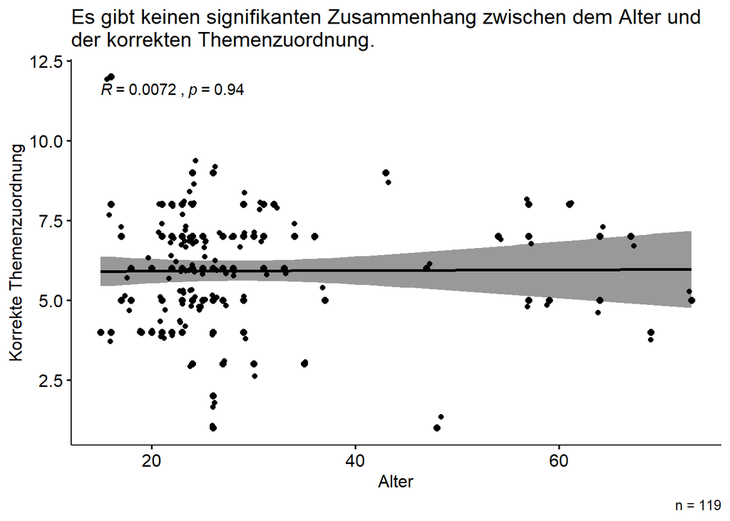

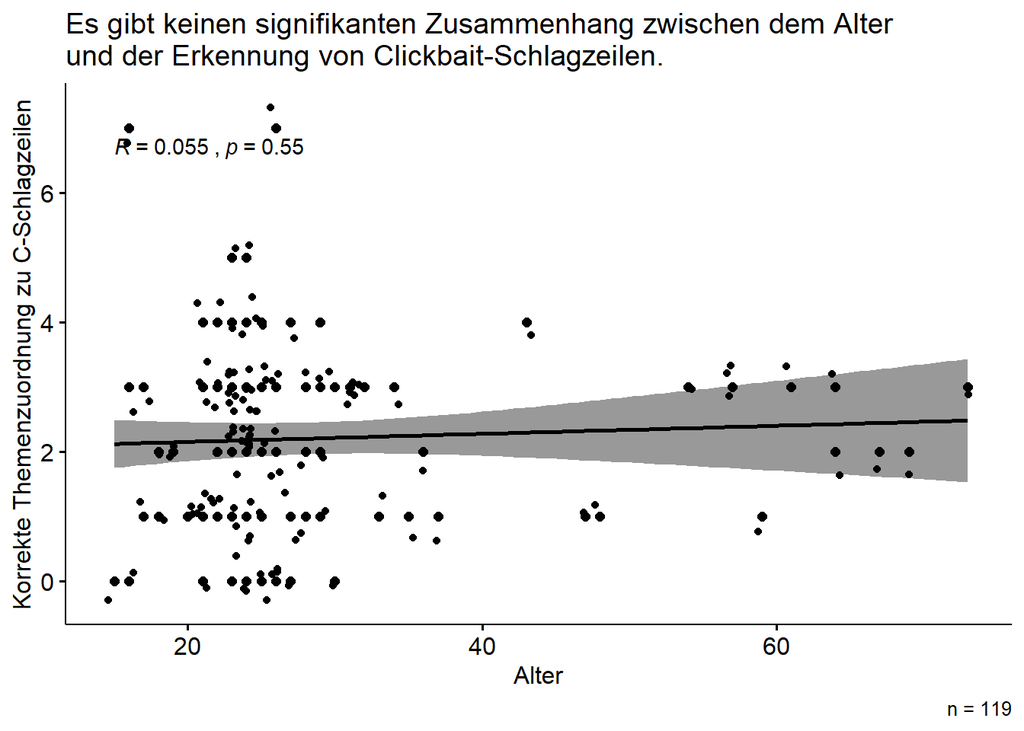

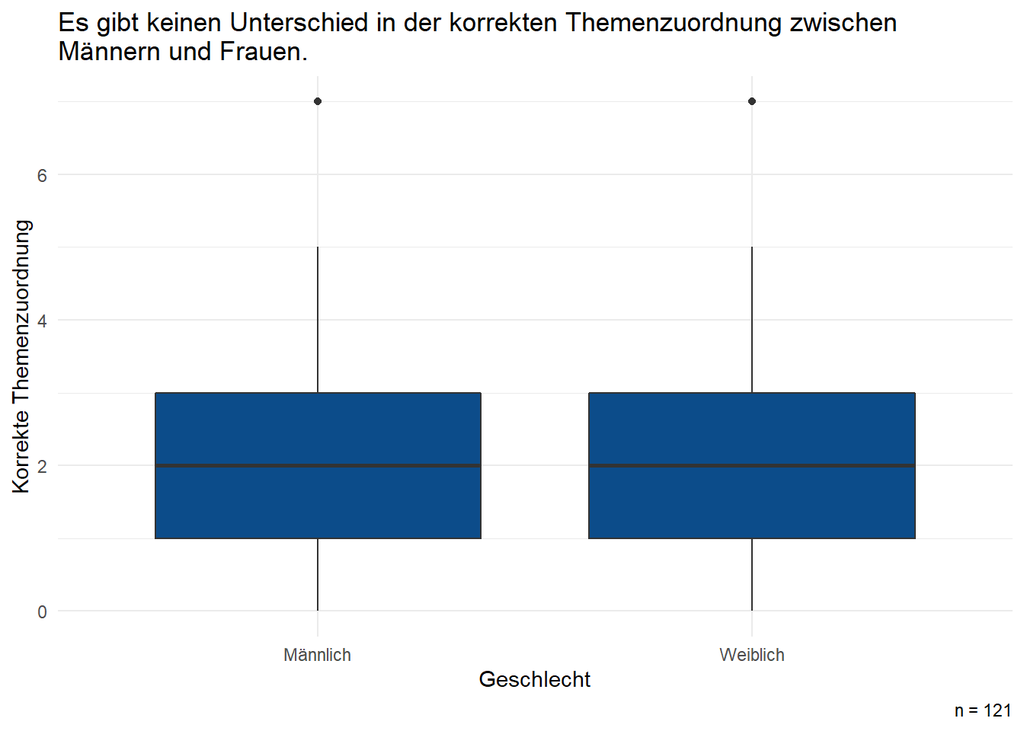

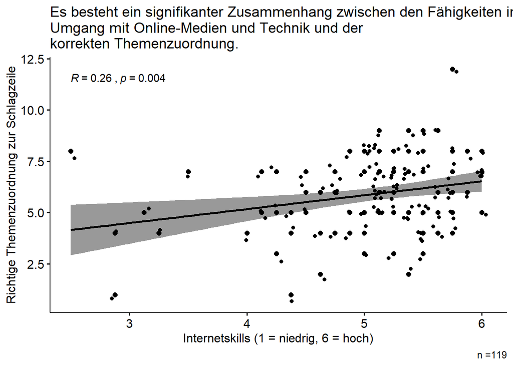

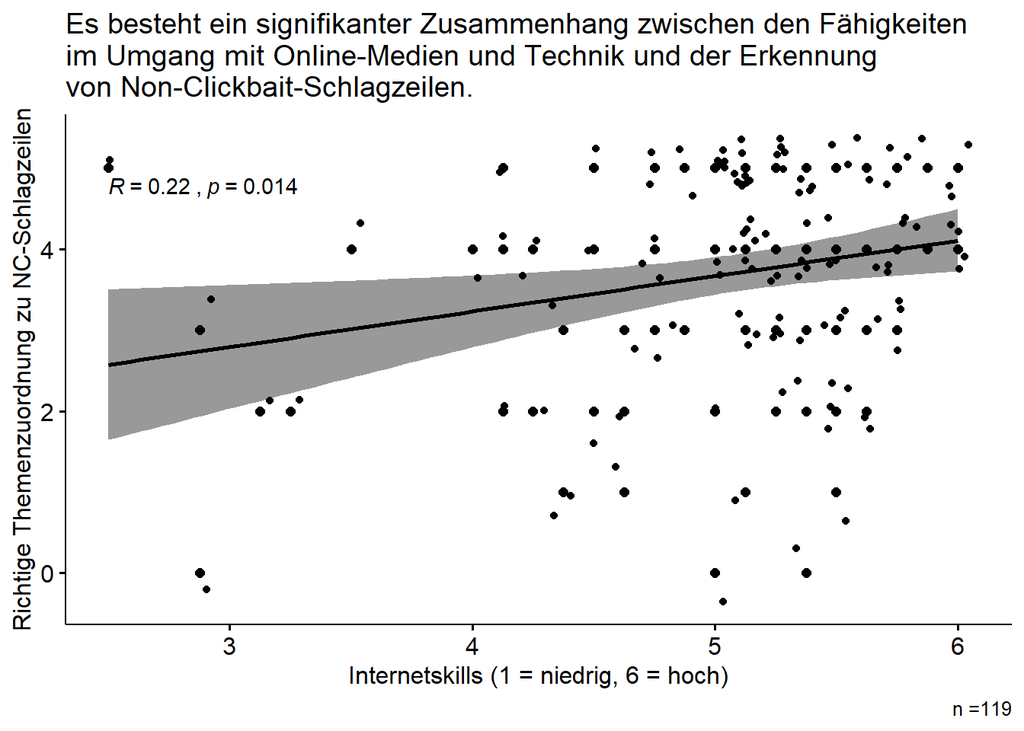

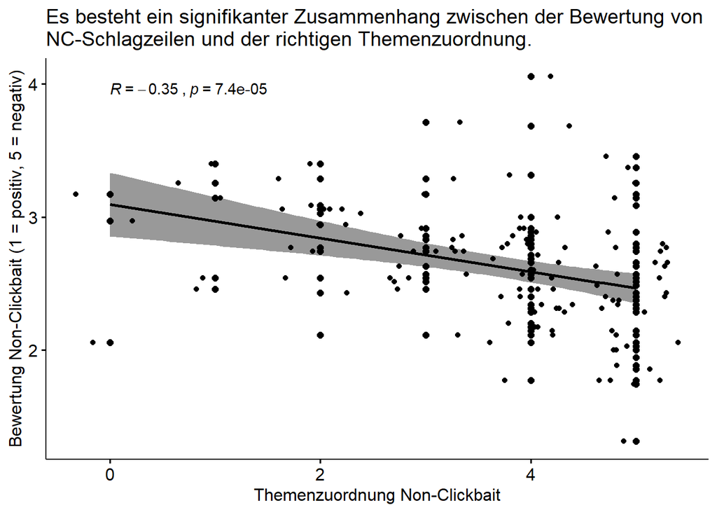

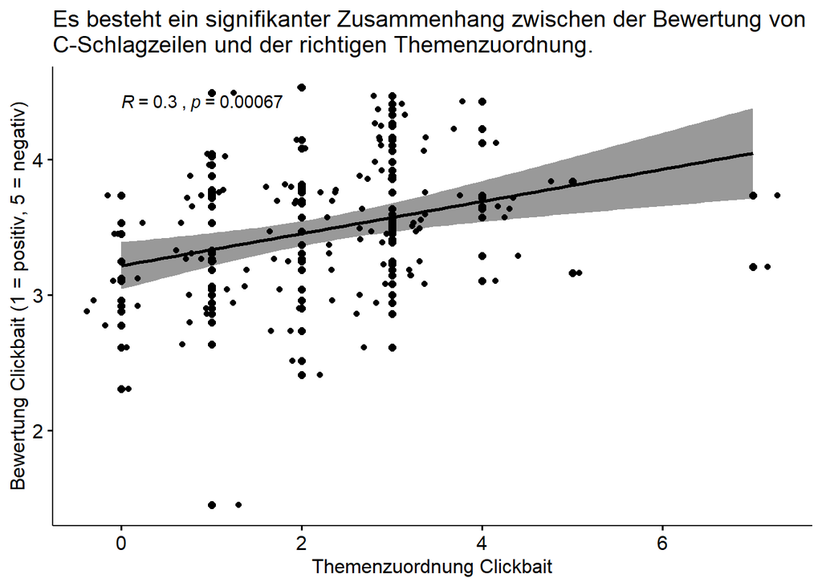

# Ergebnisse

## Zusammenhangshypothese 1

Es besteht kein signifikanter Zusammenhang zwischen dem Alter und der Erkennung von Clickbait-Schlagzeilen (r = (121) =.05, p = .55). Das Alter der Probanden steht demnach nicht in Zusammenhang mit der korrekten Zuordnung der Themeninhalte durch die Probanden.

## Unterschiedshypothese 2

In der Stichprobe konnte kein signifikanter Unterschied zwischen Männern und Frauen in der Erkennung von Clickbait-Schlagzeilen (t (116.16) = -.32, p = .75) oder Non-Clickbait-Schlagzeilen festgestellt werden (t (118.67) = 1.27, p = .21).

## Zusammenhangshypothese 3

Es besteht ein signifikanter, schwach positiver Zusammenhang zwischen den Fähigkeiten im Umgang mit Online-Medien und Technik (ISS) und der Erkennung von Non-Clickbait-Schlagzeilen (r(121) = .22, p = .01). Personen, die geübter im Umgang mit Online-Medien und Technik sind, ordnen den Non-Clickbait-Schlagzeilen demnach eher den richtigen Themeninhalt zu. Ebenso kann dieser Zusammenhang in Bezug auf die kumulierte Bewertung aller Schlagzeilen festgestellt werden (r (121) = .26, p = .004). Je höher die Fähigkeiten im Umgang mit Online-Medien und Technik sind, desto eher ordnen die Probanden den gesamten Schlagzeilen den richtigen Themeninhalt zu.

## Zusammenhangshypothese 4

Es besteht kein signifikanter Zusammenhang zwischen den Persönlihckeitsfaktoren nach Big 5 und der Erkennung von Clickbait-Schlagzeilen. Die einzelnen Persönlichkeitsfaktoren Offenheit (r (119) = -.09 p = .32), Gewissenhaftigkeit (r (119) = -.01, p = .92), Extraversion (r (119) = -.04, p = .68), Verträglichkeit (r (119) = -.04, p = .67) und Neurotizismus (r (119) = -.1, p = .28) korrelieren nicht, bis maximal sehr schwach, allerdings nicht signifikant mit der Erkennung von Clickbait-Schlagzeilen.

## Zusammenhangsyhypothese 5

Die Ergebnisse zeigen, dass sowohl zwischen der richtigen Themenzuordnung und der Bewertung der Non-Clickbait-Schlagzeilen (r (119) = -.35, p <.001) als auch zwischen der richtigen Themenzuordnung und der Bewertung von Clickbait-Schlagzeilen (r (119) = .30, p <.001) ein signifikanter Zusammenhang besteht. Bezüglich der Non-Clickbait-Schlagzeilen ist ein negativer Zusammenhang festzustellen. Je positiver die Schlagzeilen bewertet werden, desto eher ordnen die Probanden ebendiesen den richtigen Themeninhalt zu. Auffälliger sind allerdings die Ergebnisse der Clickbait-Schlagzeilen. Dabei ist ein positiver Zusammenhang festzustellen. Je negativer die Clickbait-Schlagzeilen bewertet werden, desto eher ordnen die Probanden den Schlagzeilen den richtigen Themeninhalt zu.

# Weiterführende Untersuchungen

```r
mean(datensatz$AnteilClickbait_1)
```

```
## [1] 7.330579
```

```r
sd(datensatz$AnteilClickbait_1)
```

```
## [1] 1.624748
```

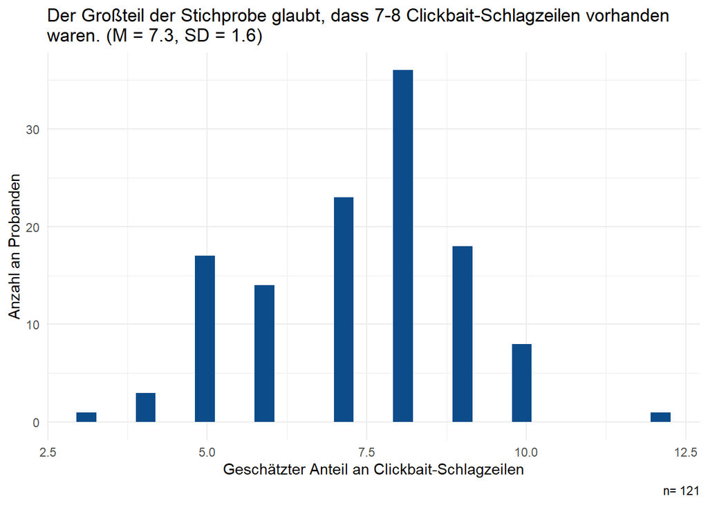

```r
ggplot(datensatz) +
 aes(x = AnteilClickbait_1) +
 geom_histogram(bins = 30L, fill = "#0c4c8a") +
  labs( x = "Geschätzter Anteil an Clickbait-Schlagzeilen", y = "Anzahl an Probanden", title = "Der Großteil der Stichprobe glaubt, dass 7-8 Clickbait-Schlagzeilen vorhanden
waren. (M = 7.3, SD = 1.6)", caption = "n= 121")+
 theme_minimal()
```

```r
#ggsave("Grafik Anteil Clickbait.jpeg")
```